# 03 Main Analysis

Nate Breznau

2022-04-15

```r
df_orig_complete <- read_csv(file = here::here("data", "df_orig_complete.csv"))
```

```r
Tbl5_m1 <- polr(factor(stdliv_next5) ~ factor(cat_age) + factor(wave) + factor(cat_age)*factor(wave), data = df_orig_complete, Hess = T)

Tbl5_m2 <- polr(factor(stdliv_next5) ~ factor(cat_age) + factor(wave) + factor(cat_age)*factor(wave) + female + factor(education) + factor(EGP6) + factor(income), data = df_orig_complete, Hess = T)

Tbl5_m3 <- polr(factor(stdliv_next5) ~ factor(cat_age) + factor(wave) + factor(cat_age)*factor(wave) + female + factor(education) + factor(EGP6) + factor(income) + pensions + unemployed + car_owner + factor(cntry), data = df_orig_complete, Hess = T)

tab_model(Tbl5_m1, Tbl5_m2, Tbl5_m3, transform = NULL, p.style = "stars", show.ci = F, show.loglik = T,  pred.labels = c("k1","k2","k3","k4","Age 30-44","Age 44-59","Age >60","Year 2007","Age 30-44*year'07", "Age 44-59*year'07", "Age >60*year'07", "Female", "Educ mid", "Educ high" ,"EGP: routine non-man", "EGP: Self", "EGP: Skilled", "EGP: Unskilled", "EGP: Farmers", "EGP: Never had a job", "Income mid", "Income high","Income missing", "Pensions and benefits","Unemployed", "Car","bulgaria", "czech", "estonia", "hungary","latvia", "lithuania", "moldova","poland", "romania", "russia","slovakia", "ukraine"), file = here::here("results", "Tbl5_rep_f.doc"))
```

factor(stdliv next 5)

factor(stdliv next 5)

factor(stdliv next 5)

Predictors

Log-Odds

Log-Odds

Log-Odds

k1

-2.51 ***

-2.45 ***

-2.21 ***

k2

-1.61 ***

-1.54 ***

-1.29 ***

k3

0.59 ***

0.68 ***

0.99 ***

k4

3.18 ***

3.30 ***

3.64 ***

Age 30-44

-0.41 ***

-0.46 ***

-0.46 ***

Age 44-59

-0.81 ***

-0.82 ***

-0.82 ***

Age >60

-0.97 ***

-0.82 ***

-0.75 ***

Year 2007

0.75 ***

0.73 ***

0.75 ***

Age 30-44*year’07

0.00

0.02

-0.02

Age 44-59*year’07

-0.11

-0.10

-0.11

Age >60*year’07

-0.38 ***

-0.40 ***

-0.39 ***

Female

-0.15 ***

-0.10 ***

Educ mid

0.08 **

0.02

Educ high

0.21 ***

0.17 ***

EGP: routine non-man

-0.08 *

-0.06

EGP: Self

0.22 ***

0.26 ***

EGP: Skilled

-0.16 ***

-0.14 ***

EGP: Unskilled

-0.17 ***

-0.13 ***

EGP: Farmers

-0.18 ***

-0.14 ***

EGP: Never had a job

-0.32 ***

-0.19 ***

Income mid

0.14 ***

0.11 ***

Income high

0.41 ***

0.36 ***

Income missing

0.21 *

0.18

Pensions and benefits

-0.09 **

Unemployed

-0.20 ***

Car

0.27 ***

bulgaria

0.02

czech

0.33 ***

estonia

0.66 ***

hungary

-0.24 ***

latvia

0.72 ***

lithuania

0.58 ***

moldova

-0.27 ***

poland

0.27 ***

romania

0.40 ***

russia

0.15 **

slovakia

0.00

ukraine

-0.12 *

Observations

35648

35648

35648

R<sup>2</sup> Nagelkerke

0.068

0.086

0.120

log-Likelihood

-45584.674

-45258.680

-44644.165

- p<0.05 ** p<0.01 *** p<0.001

```r
tab_model(Tbl5_m1, Tbl5_m2, Tbl5_m3, transform = NULL, p.style = "stars", show.ci = F, show.loglik = T,  pred.labels = c("k1","k2","k3","k4","Age 30-44","Age 44-59","Age >60","Year 2007","Age 30-44*year'07", "Age 44-59*year'07", "Age >60*year'07", "Female", "Educ mid", "Educ high" ,"EGP: routine non-man", "EGP: Self", "EGP: Skilled", "EGP: Unskilled", "EGP: Farmers", "EGP: Never had a job", "Income mid", "Income high","Income missing", "Pensions and benefits","Unemployed", "Car","bulgaria", "czech", "estonia", "hungary","latvia", "lithuania", "moldova","poland", "romania", "russia","slovakia", "ukraine"), file = here::here("results", "Tbl5_rep_f.htm"))
```

factor(stdliv next 5)

factor(stdliv next 5)

factor(stdliv next 5)

Predictors

Log-Odds

Log-Odds

Log-Odds

k1

-2.51 ***

-2.45 ***

-2.21 ***

k2

-1.61 ***

-1.54 ***

-1.29 ***

k3

0.59 ***

0.68 ***

0.99 ***

k4

3.18 ***

3.30 ***

3.64 ***

Age 30-44

-0.41 ***

-0.46 ***

-0.46 ***

Age 44-59

-0.81 ***

-0.82 ***

-0.82 ***

Age >60

-0.97 ***

-0.82 ***

-0.75 ***

Year 2007

0.75 ***

0.73 ***

0.75 ***

Age 30-44*year’07

0.00

0.02

-0.02

Age 44-59*year’07

-0.11

-0.10

-0.11

Age >60*year’07

-0.38 ***

-0.40 ***

-0.39 ***

Female

-0.15 ***

-0.10 ***

Educ mid

0.08 **

0.02

Educ high

0.21 ***

0.17 ***

EGP: routine non-man

-0.08 *

-0.06

EGP: Self

0.22 ***

0.26 ***

EGP: Skilled

-0.16 ***

-0.14 ***

EGP: Unskilled

-0.17 ***

-0.13 ***

EGP: Farmers

-0.18 ***

-0.14 ***

EGP: Never had a job

-0.32 ***

-0.19 ***

Income mid

0.14 ***

0.11 ***

Income high

0.41 ***

0.36 ***

Income missing

0.21 *

0.18

Pensions and benefits

-0.09 **

Unemployed

-0.20 ***

Car

0.27 ***

bulgaria

0.02

czech

0.33 ***

estonia

0.66 ***

hungary

-0.24 ***

latvia

0.72 ***

lithuania

0.58 ***

moldova

-0.27 ***

poland

0.27 ***

romania

0.40 ***

russia

0.15 **

slovakia

0.00

ukraine

-0.12 *

Observations

35648

35648

35648

R<sup>2</sup> Nagelkerke

0.068

0.086

0.120

log-Likelihood

-45584.674

-45258.680

-44644.165

- p<0.05 ** p<0.01 *** p<0.001

```r
#knitr::include_graphics(here::here("results", "Tbl5_rep_f.htm"))

#webshot(here::here("results", "Tbl5_rep_f.htm"), file = here::here("results", "Tbl5_rep_f.png"))

#knitr::include_graphics(here::here("results", "Tbl5_rep_f.png"))
```

## Marginal Estimates

The coefficients in the table are different from the original results, but they are also different from the Stata results (see 03_Main_Analysis_Stata.do). Clearly the ordred probit models use slightly different estimation techniques. But, the quesiton is: are the predicted values the same?

### Calculate Margins

```r
newdat <- data.frame(
  cat_age = rep(1:4, 2),
  wave = c(rep(1993, 4), rep(2007, 4)),
  female = rep(0, 8),
  education = rep(1,8),
  EGP6 = rep(1,8),
  income = rep(1,8),
  pensions = rep(mean(df_orig_complete$pensions, na.rm = T),8),
  unemployed = rep(mean(df_orig_complete$unemployed, na.rm = T),8),
  car_owner = rep(mean(df_orig_complete$car_owner, na.rm = T),8),
  cntry = "belarus") # ref cat

newdat <- cbind(newdat, predict(Tbl5_m3, newdat, type = "probs"))
```

### Import Stata Results

```r
Tbl5_m3_Stata <- read_csv(here::here("results","Tbl5_m3.csv"))
```

### Combine into Margins Comparison Table

```r
Tbl5_marg_comp <- newdat %>%
  dplyr::select(wave, cat_age, `1`, `2`, `3`, `4`, `5`)

colnames(Tbl5_marg_comp) <- c("wave", "age_cat", "fall_alot", "fall", "stay_same", "rise", "rise_alot")

# add Stata results
Tbl5_marg_comp[9:16,] <- NA
Tbl5_marg_comp$Software <- c(rep("R polr",8), rep("Stata oprobit", 8))
Tbl5_marg_comp[9:16,1:2] <- Tbl5_marg_comp[1:8,1:2]

#sort Stata data
Tbl5_m3_Stata <- Tbl5_m3_Stata[order( Tbl5_m3_Stata[,"outcome"], Tbl5_m3_Stata[,"wave"] ),]

Tbl5_marg_comp$fall_alot[9:16] <- Tbl5_m3_Stata$margin[1:8]
Tbl5_marg_comp$fall[9:16] <- Tbl5_m3_Stata$margin[9:16]
Tbl5_marg_comp$stay_same[9:16] <- Tbl5_m3_Stata$margin[17:24]
Tbl5_marg_comp$rise[9:16] <- Tbl5_m3_Stata$margin[25:32]
Tbl5_marg_comp$rise_alot[9:16] <- Tbl5_m3_Stata$margin[33:40]
```

### Comparison

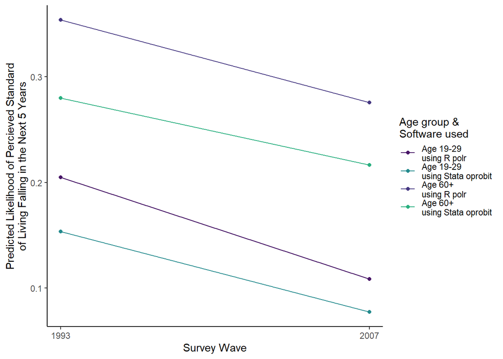

```r
Tbl5_marg_comp %>%
  subset(age_cat == 1 | age_cat == 4) %>%
  ggplot(aes(y = (fall_alot+fall), x = wave, color = interaction(Software,age_cat))) +
  geom_point() +
  geom_line() +
  labs(y = "Predicted Likelihood of Percieved Standard\nof Living Falling in the Next 5 Years", x = "Survey Wave") +
  scale_color_manual(name = "Age group &\nSoftware used",
                       values = c("#481567FF",
                                  "#238A8DFF",
                                  "#453781FF",
                                  "#29AF7FFF"),
                       labels = c("Age 19-29\nusing R polr", "Age 19-29\nusing Stata oprobit", "Age 60+\nusing R polr", "Age 60+\nusing Stata oprobit")) +
  scale_x_discrete(limits = c(1993,2007)) +
  theme_classic()
```

## Table Comparing Stata and R Margins

```r
kable_styling(kable(Tbl5_marg_comp))
```

| wave | age_cat | fall_alot | fall | stay_same | rise | rise_alot | Software |
| --- | --- | --- | --- | --- | --- | --- | --- |
| 1993 | 1 | 0.0927751 | 0.1120754 | 0.5111955 | 0.2567204 | 0.0272337 | R polr |
| 1993 | 2 | 0.1396044 | 0.1505535 | 0.5098853 | 0.1826181 | 0.0173387 | R polr |
| 1993 | 3 | 0.1888147 | 0.1808238 | 0.4819878 | 0.1362233 | 0.0121504 | R polr |
| 1993 | 4 | 0.1784101 | 0.1752032 | 0.4890246 | 0.1443496 | 0.0130125 | R polr |
| 2007 | 1 | 0.0460742 | 0.0624050 | 0.4351127 | 0.4004501 | 0.0559580 | R polr |
| 2007 | 2 | 0.0722499 | 0.0917628 | 0.4935636 | 0.3069644 | 0.0354592 | R polr |
| 2007 | 3 | 0.1088939 | 0.1264952 | 0.5154429 | 0.2262760 | 0.0228920 | R polr |
| 2007 | 4 | 0.1311603 | 0.1443632 | 0.5127259 | 0.1931386 | 0.0186120 | R polr |
| 1993 | 1 | 0.0626676 | 0.0909308 | 0.4790867 | 0.3246091 | 0.0427057 | Stata oprobit |
| 1993 | 2 | 0.1054630 | 0.1243734 | 0.5027682 | 0.2447451 | 0.0226503 | Stata oprobit |
| 1993 | 3 | 0.1464445 | 0.1480962 | 0.4993305 | 0.1922632 | 0.0138655 | Stata oprobit |
| 1993 | 4 | 0.1366441 | 0.1430050 | 0.5015386 | 0.2033232 | 0.0154891 | Stata oprobit |
| 2007 | 1 | 0.0265037 | 0.0508320 | 0.3974964 | 0.4314184 | 0.0937495 | Stata oprobit |
| 2007 | 2 | 0.0479969 | 0.0764672 | 0.4575851 | 0.3618393 | 0.0561114 | Stata oprobit |
| 2007 | 3 | 0.0808522 | 0.1064922 | 0.4943244 | 0.2864267 | 0.0319044 | Stata oprobit |
| 2007 | 4 | 0.0974332 | 0.1188876 | 0.5011741 | 0.2573054 | 0.0251997 | Stata oprobit |